# Sentiment Analysis EU commission AI act

Kristoffer Bakke Tvedt

2024-07-06

```r
library(quanteda)
library(quanteda.textstats)
```

```r
library(quanteda.textplots)
library(quanteda.textmodels)
library(tidyverse)
library(remotes)
library(quanteda.sentiment)
```

Reads the RDS file created from pdf files and filters out any papers that are not by Business or NGO

```r
df <- readRDS("data_corpus_aiact_english_new.rds")
df_business_ngo <- df%>%
  filter(type_actor %in% c("Business", "NGO"))
```

Creates a corpus from df and changes docvar Names to the actor of the paper. Displays a summary of said corpus.

```r
original_names <- df_business_ngo$actor
actor_types <- df_business_ngo$type_actor
data_corpus_aiact <- corpus(df_business_ngo)
docnames(data_corpus_aiact) <- paste(original_names, actor_types, sep = " - ")
summary(data_corpus_aiact)
```

```
## Corpus consisting of 129 documents, showing 100 documents:
##
##                              Text Types Tokens Sentences       id
##                  SAZKA - Business   595   1582        57 F2488672
##             Allied-Startups - NGO   285    601        21 F2662175
##             Civil-Liberties - NGO  1252   4899       181 F2662292
##                 Google - Business  1188   5927       154 F2662492
##                        PGEU - NGO   416   1075        27 F2662654
##                   SICK - Business   161    296        11 F2662771
##                 sanofi - Business   376    736        29 F2662846
##     Co-operative-Banks - Business  1098   4721       133 F2662901
##                Siemens - Business  1159   4317       104 F2662941
##             BlackBerry - Business   333    738        21 F2662944
##          Not-for-profit-law - NGO  1584   8604       318 F2663061
##                  Eurocities - NGO   815   2747       104 F2663127
##               Hangzhou - Business  1142   4568       109 F2663157
##         European-Disability - NGO   285    676         6 F2663268
##                 EUCOPE - Business   985   2737        90 F2663324
##              Eurosmart - Business   997   3134       125 F2663348
##                 Orange - Business   595   1567        47 F2663358
##                  Bayer - Business   335    659        21 F2663359
##  Information-Accountability - NGO  1248   5928       219 F2663380
##                 ResMed - Business   321    839        19 F2663398
##                 IDEMIA - Business   993   5226       134 F2663405
##      Hoffmann-La-Roche - Business  1667   8398       172 F2665165
##            Intesa-Bank - Business   800   2785        66 F2665169
##           Hospital-Pharmacy - NGO   287    736        20 F2665208
##          European-Radiology - NGO   243    481        17 F2665222
##                 Biogen - Business   355    679        20 F2665227
##                 OpenAI - Business   468   1043        50 F2665231
##                Workday - Business  1213   5370       172 F2665233
##                        EDRi - NGO  2776  16936       369 F2665234
##                    SAP - Business  1026   3929       122 F2665235
##        Democracy-Technology - NGO   338    712        28 F2665242
##                   Wikimedia - NGO   302    614        26 F2665256
##                     5Rights - NGO  4607  21783       642 F2665266
##                       Thorn - NGO   258    617        24 F2665284
##                    LNE - Business   616   1765        47 F2665323
##            AstraZeneca - Business   666   1868        76 F2665331
##              AlgorithmWatch - NGO  1611   6895       194 F2665406
```

[output cut: 149 more lines]

```
##            Medical-Oncology        NGO
##                      Onfido   Business
##              Siemens-Energy   Business
##               Future-ofLife        NGO
##               Hogan-Lovells   Business
##             Edtech-Alliance        NGO
##                  Trilateral   Business
##                   Microsoft   Business
##                       Nokia   Business
##                         BVI   Business
##                   Medtronic   Business
##                 Open-Future        NGO
##                 Women-in-AI        NGO
##          Evangelig-Alliance        NGO
##                    Infineon   Business
```

Creates a atoken object from corpus

```r
toks_aiact <- tokens(data_corpus_aiact)
```

Creates a dfm from token object

```r
toks_aiact2 <- tokens(data_corpus_aiact, remove_punct = T, remove_numbers = T) %>%
tokens_remove(stopwords("en")) %>%
dfm()
toks_aiact2
```

```
## Document-feature matrix of: 129 documents, 15,350 features (95.06% sparse) and 3 docvars.
##                        features
## docs                    sazka group submission ec public consultation
##   SAZKA - Business          7     7          1  4      4            1
##   Allied-Startups - NGO     0     0          0  0      0            0
##   Civil-Liberties - NGO     0     4          0  0     28            1
##   Google - Business         0     0          1  0      2            2
##   PGEU - NGO                0     1          0  0      1            1
##   SICK - Business           0     0          0  0      0            0
##                        features
## docs                    artificial intelligence ethical legal
##   SAZKA - Business               3            4       1     6
##   Allied-Startups - NGO          7            7       1     3
##   Civil-Liberties - NGO          4            4       0     0
##   Google - Business              1            2       0    11
##   PGEU - NGO                     4            4       0     1
##   SICK - Business                2            2       1     1
## [ reached max_ndoc ... 123 more documents, reached max_nfeat ... 15,340 more features ]
```

Shows most frequent terms by document

```r
textstat_frequency(toks_aiact2, n = 10, groups = actor)
```

```
##               feature frequency rank docfreq                          group
## 1            children       175    1       1                        5Rights
## 2             digital       108    2       1                        5Rights
## 3              social       103    3       1                        5Rights
## 4                 use        81    4       1                        5Rights
## 5               media        79    5       1                        5Rights
## 6              people        70    6       1                        5Rights
## 7               young        70    6       1                        5Rights
## 8              design        69    8       1                        5Rights
## 9              online        67    9       1                        5Rights
## 10         persuasive        65   10       1                        5Rights
## 11                 ai        54    1       1                            ABB
## 12             system        30    2       1                            ABB
## 13            systems        24    3       1                            ABB
## 14             safety        20    4       1                            ABB
```

[output cut: 1276 more lines]

Groups the dfm by type_actor

```r
toks_aiact3 <- toks_aiact2 %>%
dfm_group(groups = type_actor)
```

Keyness analysis

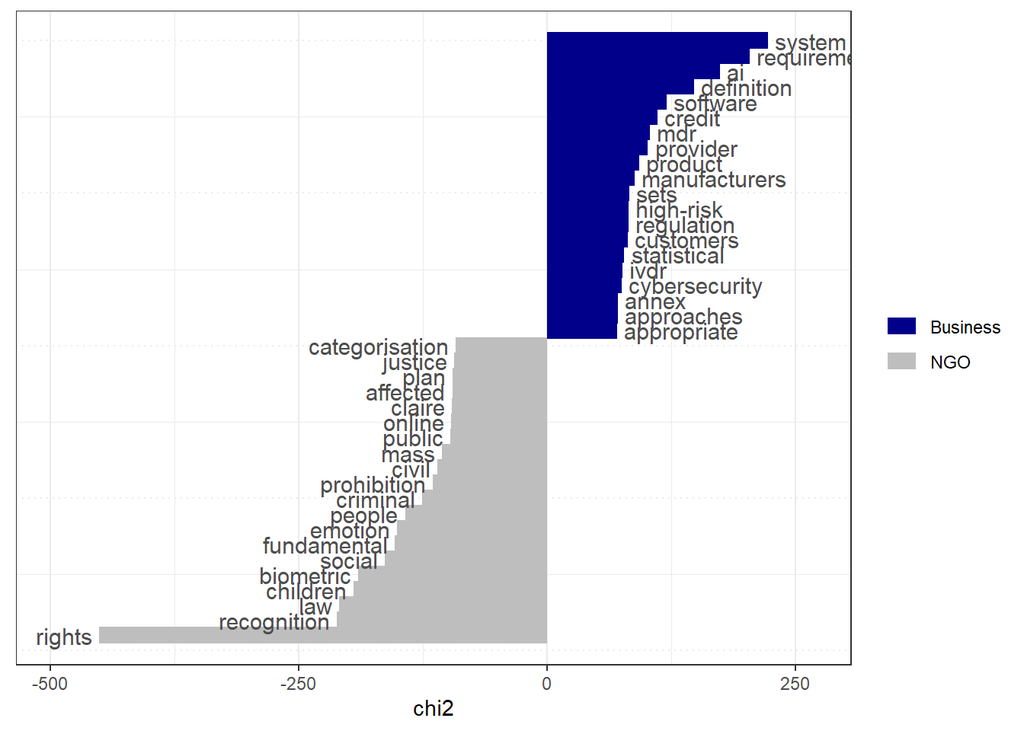

```r
tstat_key <- textstat_keyness(toks_aiact3, measure = "chi2")
tplot_key <- textplot_keyness(tstat_key, n = 20)
tplot_key
```

token object based on the first token object

```r
toks_aiact4 <- toks_aiact %>%
tokens_remove(stopwords("en"), padding = T )
```

Collocation analysis

```r
col_aiact <- textstat_collocations(toks_aiact4, size = 2:3)
```

Looks for multiword expressions and creates a new token object from this

```r
toks_aiact5 <- tokens(col_aiact$collocation)
toks_aiact6 <- tokens(toks_aiact4) %>%
tokens_compound(pattern = as.phrase(toks_aiact5))
toks_aiact6
```

```
## Tokens consisting of 129 documents and 3 docvars.
## SAZKA - Business :
##  [1] "SAZKA_Group"             "submission"
##  [3] ""                        ""
##  [5] "EC"                      "public_consultation"
##  [7] ""                        "Artificial_Intelligence"
##  [9] "–"                       "ethical"
## [11] ""                        "legal_requirements"
## [ ... and 1,383 more ]
##
## Allied-Startups - NGO :
##  [1] "Feedback_reference"
##  [2] "F2662175"
##  [3] "Submitted"
##  [4] ""
##  [5] "13"
##  [6] "July_2021_Submitted"
##  [7] ""
##  [8] "Manon"
##  [9] "Tabaczynsky"
## [10] "User_type_Non-governmental_organisation"
## [11] "("
## [12] "NGO"
## [ ... and 491 more ]
##
## Civil-Liberties - NGO :
##  [1] "RECOMMENDATIONS"                     ""
##  [3] ""                                    "COMMISSION’S_AI_REGULATION_PROPOSAL"
##  [5] "12"                                  "JULY_2021"
##  [7] ""                                    "CIVIL_LIBERTIES_UNION"
##  [9] ""                                    "EUROPE"
## [11] "Recommendations"                     ""
## [ ... and 4,173 more ]
##
## Google - Business :
##  [1] "Consultation"       ""                   ""
##  [4] "EU_AI_Act_Proposal" "Google’s"           "submission"
##  [7] "July"               "15"                 ","
## [10] "2021_Table"         ""                   "Contents"
## [ ... and 5,102 more ]
##
## PGEU - NGO :
##  [1] "PGEU"                         "feedback"
##  [3] ""                             ""
##  [5] "European_Commission_Proposal" ""
##  [7] ""                             "EU_Regulation"
##  [9] ""                             "Artificial_Intelligence"
## [11] ""                             "Pharmaceutical"
## [ ... and 908 more ]
##
## SICK - Business :
##  [1] "Feedback_reference"              "F2662771"
##  [3] "Submitted"                       ""
##  [5] "22_July_2021_Submitted"          ""
##  [7] "Volker"                          "Schaber"
##  [9] "User_type_Company"               "/"
## [11] "business_Organisation"           "SICK_AG_Organisation_size_Large"
## [ ... and 232 more ]
##
## [ reached max_ndoc ... 123 more documents ]
```

Removes punctuation characters, punctuation, and symbols from previous token object and trim it by including only terms that appear at least three times

```r
toks_aiact7 <- tokens(toks_aiact6, remove_punct = T, remove_symbols = T) %>%
  dfm() %>%
  dfm_trim(min_termfreq = 3)
toks_aiact7
```

```
## Document-feature matrix of: 129 documents, 10,033 features (93.33% sparse) and 3 docvars.
##                        features
## docs                         sazka_group submission ec public_consultation
##   SAZKA - Business       469           3          1  2                   1
##   Allied-Startups - NGO  234           0          0  0                   0
##   Civil-Liberties - NGO 1629           0          0  0                   0
##   Google - Business     2134           0          1  0                   0
##   PGEU - NGO             381           0          0  0                   0
##   SICK - Business         93           0          0  0                   0
##                        features
## docs                    artificial_intelligence ethical legal_requirements
##   SAZKA - Business                            2       1                  4
##   Allied-Startups - NGO                       1       1                  1
##   Civil-Liberties - NGO                       0       0                  0
##   Google - Business                           0       0                  0
##   PGEU - NGO                                  4       0                  0
##   SICK - Business                             1       1                  1
##                        features
## docs                    ec_proposal artificial_intelligence_act
##   SAZKA - Business                2                           1
##   Allied-Startups - NGO           0                           4
##   Civil-Liberties - NGO           0                           0
##   Google - Business               0                           0
##   PGEU - NGO                      0                           0
##   SICK - Business                 0                           0
## [ reached max_ndoc ... 123 more documents, reached max_nfeat ... 10,023 more features ]
```

Wordfish analysis

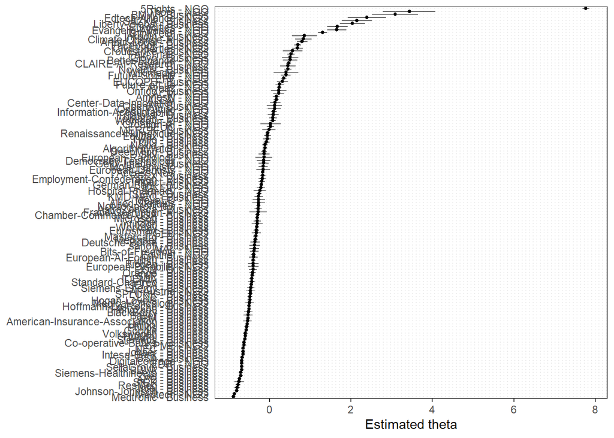

```r
aiact_wf <- textmodel_wordfish(toks_aiact7, dir = c(6,5))
textplot_scale1d(aiact_wf, groups = aiact_wf$type_actor)
```

```r
summary(aiact_wf)
```

```
##
## Call:
## textmodel_wordfish.dfm(x = toks_aiact7, dir = c(6, 5))
##
## Estimated Document Positions:
##                                              theta       se
## SAZKA - Business                           2.14692 0.187300
## Allied-Startups - NGO                     -0.26631 0.082029
## Civil-Liberties - NGO                      0.69097 0.065873
## Google - Business                         -0.56546 0.017352
## PGEU - NGO                                -0.32277 0.056949
## SICK - Business                           -0.74468 0.060843
## sanofi - Business                         -0.36558 0.065391
## Co-operative-Banks - Business             -0.62136 0.017987
## Siemens - Business                        -0.59998 0.019566
## BlackBerry - Business                     -0.51554 0.052895
## Not-for-profit-law - NGO                  -0.27035 0.024387
## Eurocities - NGO                           1.66824 0.127249
## Hangzhou - Business                       -0.50608 0.021937
## European-Disability - NGO                 -0.39783 0.066837
## EUCOPE - Business                          0.31809 0.067884
## Eurosmart - Business                      -0.32105 0.035088
## Orange - Business                         -0.40922 0.041618
## Bayer - Business                          -0.52011 0.056431
## Information-Accountability - NGO           0.10797 0.038336
## ResMed - Business                         -0.76896 0.032287
## IDEMIA - Business                         -0.43824 0.026966
## Hoffmann-La-Roche - Business              -0.49991 0.016076
## Intesa-Bank - Business                    -0.65102 0.022195
## Hospital-Pharmacy - NGO                   -0.23761 0.074651
## European-Radiology - NGO                  -0.13444 0.105856
## Biogen - Business                         -0.39547 0.065857
## OpenAI - Business                          0.12340 0.093383
## Workday - Business                        -0.30665 0.025752
## EDRi - NGO                                -0.67685 0.009505
## SAP - Business                            -0.41747 0.025724
## Democracy-Technology - NGO                -0.14274 0.088026
## Wikimedia - NGO                            0.40670 0.152176
## 5Rights - NGO                              7.76720 0.043736
## Thorn - NGO                                3.43299 0.328145
```

[output cut: 97 more lines]

```
##               sazka_group submission       ec public_consultation
## beta -0.01686      0.1705   -0.08166 -0.08134             -0.1348
## psi   7.19269     -3.9200   -2.13327 -0.56470             -1.3410
##      artificial_intelligence  ethical legal_requirements ec_proposal
## beta                  -0.102  0.07147           -0.08718     0.05044
## psi                    1.254 -0.37654           -1.17714    -3.27454
##      artificial_intelligence_act       1  short      sg     one europe’s
## beta                     -0.8348 -0.1283  0.131  0.1709 0.04951  -0.1117
## psi                      -0.1431  1.3505 -2.125 -2.6213 0.64205  -1.3122
##      growing lottery companies primarily focused  national   games lotteries
## beta  0.2625  0.1706   0.05774   0.03414  0.0461  0.002023  0.4491     0.305
## psi  -2.3626 -3.6325   0.31538  -1.98437 -1.5141 -0.655858 -3.5582    -4.319
##       online secondary    focus digital gambling   leading  market
## beta  0.3181    0.2287 -0.06014  0.2533   0.3054 -0.001661 -0.2807
## psi  -1.0698   -2.7514  0.03080 -0.8532  -2.7113 -0.781681  0.8093
```

Creates new object and applies Lexicoder Sentiment Dictionary

```r
toks_lsd <- toks_aiact %>%
  tokens_lookup(dictionary = data_dictionary_LSD2015) %>%
  dfm()
```

gets sentiment score

```r
aiact_ss <- textstat_polarity(toks_lsd, data_dictionary_LSD2015)
aiact_ss$type_actor <- toks_lsd$type_actor
aiact_ss
```

```
##                                        doc_id    sentiment type_actor
## 1                            SAZKA - Business  0.346715604   Business
## 2                       Allied-Startups - NGO  0.608247737        NGO
## 3                       Civil-Liberties - NGO -0.100083459        NGO
## 4                           Google - Business  0.783613270   Business
## 5                                  PGEU - NGO  2.470091564        NGO
## 6                             SICK - Business  0.243622083   Business
## 7                           sanofi - Business  0.788457360   Business
## 8               Co-operative-Banks - Business  0.928975891   Business
## 9                          Siemens - Business  0.447900151   Business
## 10                      BlackBerry - Business  1.894174475   Business
## 11                   Not-for-profit-law - NGO  0.178064633        NGO
## 12                           Eurocities - NGO  1.122310080        NGO
## 13                        Hangzhou - Business  0.864062712   Business
## 14                  European-Disability - NGO  0.782274960        NGO
```

[output cut: 115 more lines]

Creates new variable with only Business and NGO sentiment score to measure mean and median

```r
aiact_ss_business <- aiact_ss %>%
  filter(type_actor %in% c("Business"))
aiact_ss_ngo <- aiact_ss %>%
  filter(type_actor %in% c("NGO"))
mean(aiact_ss_business$sentiment)
```

```
## [1] 0.8877756
```

```r
median(aiact_ss_business$sentiment)
```

```
## [1] 0.8714926
```

```r
mean(aiact_ss_ngo$sentiment)
```

```
## [1] 0.7134341
```

```r
median(aiact_ss_ngo$sentiment)
```

```
## [1] 0.7539106
```

plots the sentiment scores

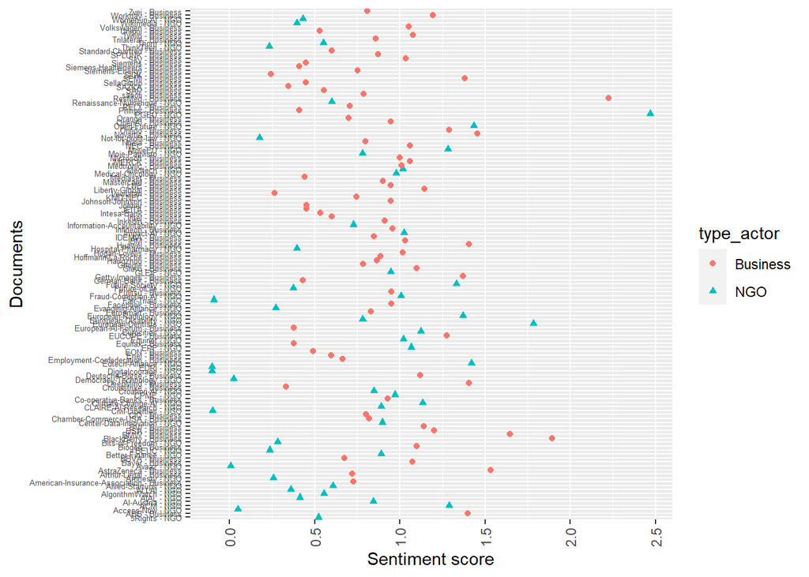

```r
ggplot(data = aiact_ss, aes(x=sentiment, y=doc_id, color = type_actor, shape = type_actor)) + geom_point() + theme(axis.text.x = element_text(angle = 90, vjust = 0.5, hjust = 0.5))+ labs(x="Sentiment score", y="Documents")+ theme(axis.text.y = element_text(size = 5))
```

Gets the 50 most used postitive words

```r
toks_aiact8 <- tokens(data_corpus_aiact) %>%
tokens_keep(pattern = data_dictionary_LSD2015$positive) %>%
  dfm()
topfeatures(toks_aiact8, n=50)
```

```
##       rights intelligence       ensure       safety   protection   innovation
##         1241          923          640          522          485          442
##      provide         well     relevant      support        right   compliance
##          363          358          332          322          297          278
##      quality     learning  significant    effective       create         like
##          265          261          236          222          208          200
##      ethical         help   principles       credit     ensuring         best
##          194          194          190          188          177          176
##        trust       better     benefits     accuracy  responsible  opportunity
##          166          162          160          159          155          155
##      respect    competent  trustworthy         free      benefit   validation
##          154          154          149          146          143          143
##  coordinated      protect   understand        civil    essential     welcomes
##          139          136          135          134          133          133
##      welcome   accessible      achieve    providing      improve    knowledge
##          132          132          131          124          123          123
##     creating         open
##          120          120
```

Gets the 50 most used negative words

```r
toks_aiact9 <- tokens(data_corpus_aiact) %>%
tokens_keep(pattern = data_dictionary_LSD2015$negative) %>%
  dfm()
topfeatures(toks_aiact9, n=50)
```

```
##             risk       artificial            risks        oversight
##             1195              903              638              259
##             harm             bias       prohibited          limited
##              241              226              221              215
##          against      prohibition              too            avoid
##              194              174              171              167
##         criminal   discrimination           errors         affected
##              160              156              141              133
##       risk-based       challenges             lack         critical
##              126              122              118              108
##            harms      uncertainty        difficult          concern
##              108              105              102              100
##        concerned          unclear           burden     implications
##               93               91               91               86
##     prohibitions     unacceptable      limitations          harmful
##               84               83               81               76
##           biases   discriminatory         negative     insufficient
##               65               64               64               63
##      problematic            limit disproportionate        liability
##               63               60               59               55
##      unnecessary           limits        challenge          adverse
##               55               54               53               52
##       impossible           threat       complexity         prohibit
##               51               50               50               49
##         disagree            vague
##               49               48
```